# Non-Life Insurance - Final project

Klemen Hovnik and Manca Strgar

# PART 1

# 1 Importing dataset

First, we need to import data from the file `Assignment.csv` into R. The file contains 163,657 rows with 16 variables. Every row represents an individual policyholder in our portfolio. One of most important columns are `nbrtotc`(number of claims for indiviudual policyholder) and `chargtot` (value of all claims for individual policyholder) as they represent frequency and severity, the amounts we are going to be fitting with models in this project. Let’s have a look at our dataset:

| AGEPH | CODPOSS | duree | lnexpo | nbrtotc | nbrtotan | chargtot | agecar | sexp | fuelc | split | usec | fleetc | sportc | coverp | powerc |
| --- | --- | --- | --- | --- | --- | --- | --- | --- | --- | --- | --- | --- | --- | --- | --- |
| 64 | 1000 | 1.0000000 | 0.0000000 | 0 | 0.00000 | 0.0000 | 2-5 | Female | Petrol | Once | Private | No | No | MTPL+ | 66-110 |
| 28 | 1000 | 0.0465753 | -3.0666840 | 1 | 21.47059 | 155.9746 | 6-10 | Female | Petrol | Twice | Private | No | No | MTPL | 66-110 |
| 58 | 1000 | 0.4027397 | -0.9094648 | 0 | 0.00000 | 0.0000 | >10 | Female | Petrol | Thrice | Private | No | No | MTPL | <66 |
| 37 | 1030 | 0.1698630 | -1.7727630 | 0 | 0.00000 | 0.0000 | 2-5 | Female | Petrol | Once | Professional | No | No | MTPL+++ | 66-110 |
| 29 | 1030 | 1.0000000 | 0.0000000 | 0 | 0.00000 | 0.0000 | 6-10 | Female | Petrol | Once | Private | No | No | MTPL+ | <66 |
| 25 | 1030 | 0.2958904 | -1.2177661 | 0 | 0.00000 | 0.0000 | >10 | Female | Petrol | Twice | Private | Yes | No | MTPL+ | 66-110 |

As it can be seen, the column names are not formated. So, we could rename colums in our dataset to make it easier to work with. We will rename the column `nbrtotc` into `nclaims` as the number of claims, and `duree` into `expo` as exposure. For easier programming we will also rename `ageph` and `sexp` into `age` and `sex`. We also renamed `chargtot` into `amount`. For further analysis we will also replace `0` with `NA` in `amount` column, because we will need this kind of formatting for when we will try to fit severity later on.

| age | codposs | expo | lnexpo | nclaims | nbrtotan | amount | agecar | sex | fuelc | split | usec | fleetc | sportc | coverp | powerc |
| --- | --- | --- | --- | --- | --- | --- | --- | --- | --- | --- | --- | --- | --- | --- | --- |
| 64 | 1000 | 1.0000000 | 0.0000000 | 0 | 0.00000 | NA | 2-5 | Female | Petrol | Once | Private | No | No | MTPL+ | 66-110 |
| 28 | 1000 | 0.0465753 | -3.0666840 | 1 | 21.47059 | 155.9746 | 6-10 | Female | Petrol | Twice | Private | No | No | MTPL | 66-110 |
| 58 | 1000 | 0.4027397 | -0.9094648 | 0 | 0.00000 | NA | >10 | Female | Petrol | Thrice | Private | No | No | MTPL | <66 |
| 37 | 1030 | 0.1698630 | -1.7727630 | 0 | 0.00000 | NA | 2-5 | Female | Petrol | Once | Professional | No | No | MTPL+++ | 66-110 |
| 29 | 1030 | 1.0000000 | 0.0000000 | 0 | 0.00000 | NA | 6-10 | Female | Petrol | Once | Private | No | No | MTPL+ | <66 |
| 25 | 1030 | 0.2958904 | -1.2177661 | 0 | 0.00000 | NA | >10 | Female | Petrol | Twice | Private | Yes | No | MTPL+ | 66-110 |

# 2 Empirical analysis

At the begining of our empirical analysis, we will calculate the empirical claim frequency. Empirical claim frequency rate is the anticipated percentage of insured that will make claims against insurance and the number of claims they will make during a certain period. So we calculate it as
$$emperical\ claim\ frequency = \frac{\sum{number\ of\ claims}}{\sum{exposure}}$$

| emp_freq |
| --- |
| 0.1393355 |

We can see that our empirical claim frequency is low, so we will not expect a large number of claims per individual policyholder in our portfolio.

To have a better understanding of our data we can make a graphic presentation of it. Column `nclaims` in our data represents the number of claims for every individual in our portfolio. This is a very important information for building our model. We can observe that in majority of the cases we have zero claims per policy. We can also compute the mean and variance of `nclaims`, that will confirm that.

|  | nclaims |
| --- | --- |
| mean | 0.1239788 |
| variance | 0.1351269 |

We see that mean is really close to zero. But to convince you even more that the majority of the policies have zero claims, we can show you in a graph. Graph below actually shows us that almost 150,000 of policies have zero claims and the number of policies that have more than zero claims is very low.

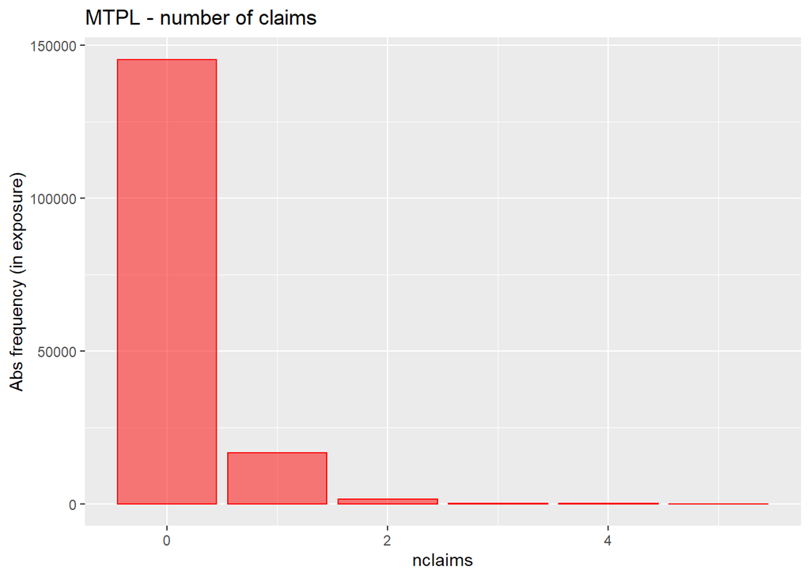

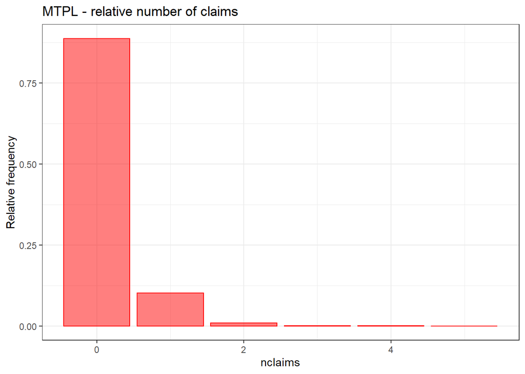

We can also group the claims by gender. In the result below we see that females are in our case more risky, because they have slightly higher mean empirical frequency. Generally speaking this is probably quite unusual, as most of the statistics would show that men are more risky drivers than women.

| sex | emp_freq |
| --- | --- |
| Female | 0.1484148 |
| Male | 0.1361295 |

We played around with `nclaim`, but this is not the only data that we have. So let’s graphically show side by side relative frequency for our given data.

First, the graph we already seen and it show the relative frequency of claim number. We see, as already discused, that the majority of policyholders have zero claims and as the number of claims rises, the frequency falls.

The second graph shows the exposure of our policyholders. The exposure represents the fraction of the year that the individual policyholder is insured. We can see, that most of policyholders are ensured for the whole year. Third graph shows the severity of the claims. As most of the policyholders have zero claims, it does not come as a surprise that the higher relative frequency for severity is at zero. And also the higher the amount, the lower is the frequency as claims of high altitude rearly happen.

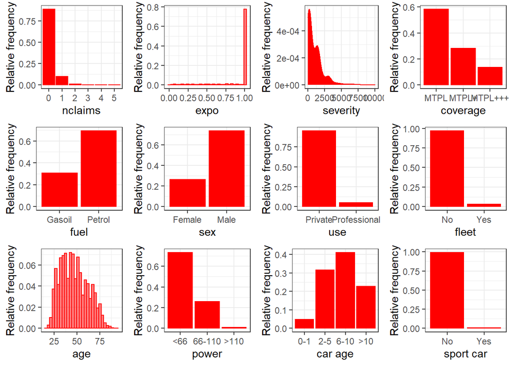

Among our data, we also have an information about the postal code of Belgium in which the claim happened. We can show this in a map. We can see that most of the claims happen in urban areas.

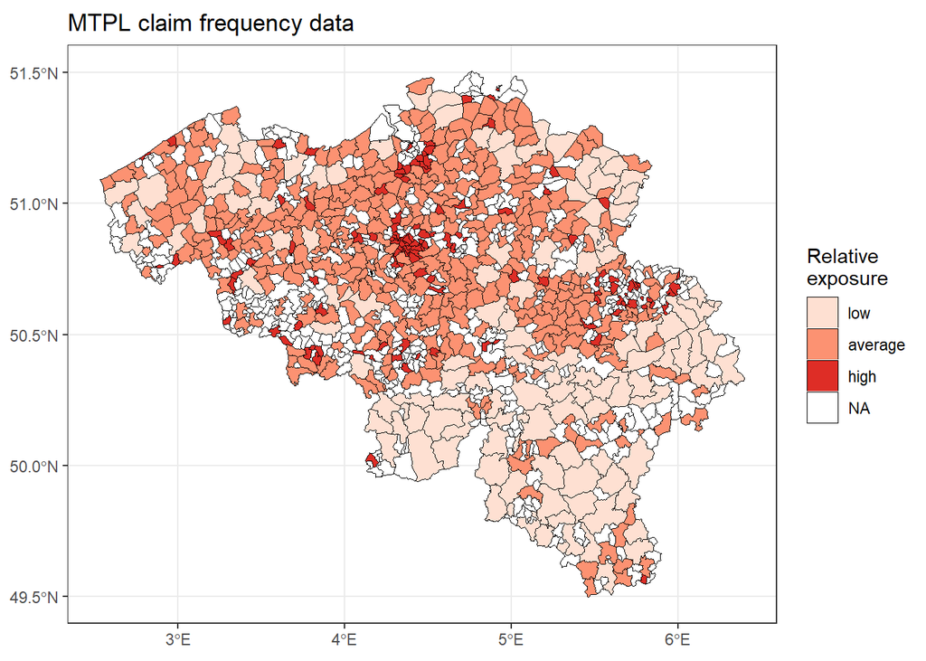

# 3 The construction of a (technical) tariff structure with Generalized Linear Model (GLM)

To construct a (technical) tariff structure we first need to fit frequency and severity of claims in our portfolio. We decided that we will first do this with GLMs. To fit frequency with GLM we can use Poisson or Negative Binomial distribution. The best suitable distributios for severity fitting are Log-normal and Gamma distributions. For our exercise we decided that we will fit frequency with Poisson distribution and severity with Gamma distribution.

First lets build a Poisson GLM for number of claims, so we are building frequency model. We will built a GLM for number of claims as a function of a covariate gender, we will also include the log of exposure as an offset. We will do that with `glm` function.

In `glm` we can define one variable as a function of covariates. In our example we will define `nclaims` as a function of covariate `sex`. As an offset we will include the log of `expo` (log of exposure). Then we need to define which family of distributions we want to use and as said before we will use Poisson distribution, which has a link function - logaritmic function. And finally, we need to determine our data set, which is `mtpl`. We can write this as:
$$Y \sim Poisson\ \ with \\
log(E(Y)) = x'* \beta, or \\
E(Y) = e^{x'*\beta}$$

When we run the code we get the following expected frequencies for females and males.

|  | Emp. frequency |
| --- | --- |
| Female.(Intercept) | 0.1484148 |
| Male.(Intercept) | 0.1361295 |

Here we modelled number of claims with sex and for empirical frequency of claims per individual geneder. If we now look back at the begining of our report, we already analysed empirical frequency grouped by the gender. We can see, that we got the same result for empirical frequency by gender, as we did in the first part of the report. This is because we constructed the GLM with only one covariance (sex). If more were used the result would be different.

In RStudio we also have a `predict` function that alows us to use our GLM model on new data frames. We can now define two new data frames, one being male drivers with exposure 1 and the other being the female drivers with exposure 1. And we can use `predict` functions on these two new data frames, we only need to yet determin the type of `predict` function. This means that we can do predictions on different levels: 1.level: “response” ~ we will construct the fitted value of expected value we are ftting (Y from above). We want to know, given the covariates that we observed for our X, what is the fitted value of expected outcome. 2.level: “terms” ~ This allows us to isolate one specific covariate and it’s associated effect. 3.level: “link” ~ We calculate the betas, we do not take the inverse of our link function. We will make a transition to the scale of response. We will always predict on a level of response, because we are interested in the fitted value of expected outcome.

|  | predicted frequency |
| --- | --- |
| Female.1 | 0.1484148 |
| Male.1 | 0.1361295 |

We can see, that even on new data frame we get the same frequency per gender as before.

Now we will build a model for severity information. For severity, the best distributions for fitting are Gamma and Log-normal distribution. We decided to use Gamma distribution for severity fitting. So for severity we will analyse variable `amount` in our mtpl data. We will again use only one explanatory variable - sex.

|  | Emp. severity |
| --- | --- |
| Female.(Intercept) | 3175.208 |
| Male.(Intercept) | 2708.911 |

We can also use `predict` function for severity and calculated empirical severity on before determend new data sets (male and female driver with exposure 1).

|  | predicted severity |
| --- | --- |
| Female.1 | 3175.208 |
| Male.1 | 2708.911 |

We can see that also with the `predict` function, we get the same values.

Now, that we’ve seen how `glm` and `predict` functions work, let’s try to fit frequency (`nclaims`) with our given covariates. We choose 20 different models for our model fitting. Chosen models are shown in the table below. But we also need to determen which criteria we will use to determine the best model. We decided that as a criteria we will use AIC.

The Akaike information criterion (AIC) is an estimator of prediction error and provides relative quality of statistical models for a given set of data. AIC estimates the quality of each model which we can relative compare to each of the other models.The preferred model is the one with the minimum AIC value. We will use already build in functin `AIC` to determin the AIC value for every chosen model.

If we shortly describe our thought process while determining the model. We firstly used all the covariates for fitting the number of claims. Than in individual models we left out one of the covariates, to see if all of them make a significant difference in our modeled variable. The ones that did not make a significat impact on our frequeny, we left out. Than we also tried some interations between covariates. We tried the ones that we thought that are most important. Everytime that we got a model that was better than one before (so it had lower AIC) we build on that model, so that we really tried to get the best possible model we could.

| model_name | model | AIC |
| --- | --- | --- |
| freq_glm_1 | 1 + age + sex + codposs + agecar + fuelc + split + usec + fleetc + sportc + coverp + powerc | 126165.7 |
| freq_glm_2 | 1 + age + codposs + agecar + fuelc + split + usec + fleetc + sportc + coverp + powerc | 126168.5 |
| freq_glm_3 | 1 + age + sex + codposs + agecar + fuelc + split + fleetc + sportc + coverp + powerc | 126164.5 |
| freq_glm_4 | 1 + age + sex + age:sex + codposs + agecar + fuelc + split + fleetc + sportc + coverp + powerc | 126144.1 |
| freq_glm_5 | 1 + age + sex + age:sex + age:powerc + codposs + agecar + fuelc + split + fleetc + sportc + coverp + powerc | 126145.7 |
| freq_glm_6 | 1 + age + sex + age:sex + codposs + agecar + fuelc + split + sportc + coverp + powerc | 126145 |
| freq_glm_7 | 1 + age + sex + age:sex + codposs + agecar + fuelc + split + fleetc + sportc + powerc | 126225.2 |
| freq_glm_8 | 1 + age + sex + age:sex + codposs + agecar + split + fleetc + sportc + coverp + powerc | 126243.5 |
| freq_glm_9 | 1 + age + sex + age:sex + codposs + fuelc + split + fleetc + sportc + coverp + powerc | 126196.3 |
| freq_glm_10 | 1 + age + sex + age:sex + agecar + fuelc + split + fleetc + sportc + coverp + powerc | 126247.4 |
| freq_glm_11 | 1 + age + sex + age:sex + codposs + agecar + fuelc + split + fleetc + coverp + powerc | 126143.1 |
| freq_glm_12 | 1 + age + sex + age:sex + codposs + agecar + fuelc + split + fleetc + coverp | 126172.3 |
| freq_glm_13 | 1 + age + sex + age:sex | 126873.1 |
| freq_glm_14 | 1 + age + sex + age:sex + codposs + agecar + fuelc + fleetc + coverp + powerc | 126494.5 |
| freq_glm_15 | 1 + age + sex + age:sex + codposs + agecar + fuelc + agecar:fuelc + split + fleetc + coverp + powerc | 126132.7 |
| freq_glm_16 | 1 + age + sex + age:sex + codposs + agecar + fuelc + agecar:fuelc + split + fleetc + coverp + powerc + sex:powerc | 126131.2 |
| freq_glm_17 | 1 + age + sex + codposs + agecar + fuelc + agecar:fuelc + split + fleetc + coverp + powerc + age:sex+ sex:powerc + age:codposs | 126132.9 |
| freq_glm_18 | 1 + age + sex + codposs + agecar + fuelc + split + fleetc + coverp + powerc + age:sex+ agecar:fuelc+ sex:powerc + age:split | 126108.6 |
| freq_glm_19 | 1 + age + sex + codposs + agecar + fuelc + split + fleetc + coverp + powerc + age:sex+ agecar:fuelc+ sex:powerc + age:split + age:agecar | 126104.3 |
| freq_glm_20 | 1 + age + sex + codposs + agecar + fuelc + split + fleetc + coverp + powerc + age:sex+ agecar:fuelc+ sex:powerc + age:split + age:agecar + fuelc:coverp | 126106.2 |

And now we can select the model with lowest AIC as the best model amoung our models for the frequency fitting. And this model is shown in the table below.

|  | model_name | model | AIC |
| --- | --- | --- | --- |
| 19 | freq_glm_19 | 1 + age + sex + codposs + agecar + fuelc + split + fleetc + coverp + powerc + age:sex+ agecar:fuelc+ sex:powerc + age:split + age:agecar | 126104.3 |

Now we have fitted frequency. But to determine the pure premium we also have to fit severity of claims in our portfolio. We did that with the same thought process as for severity.

In the table we show our 20 selected models.

| model_name | model | AIC |
| --- | --- | --- |
| sev_glm_1 | 1 + age + sex + codposs + agecar + fuelc + split + usec + fleetc + sportc + coverp + powerc | 303002.9 |
| sev_glm_2 | 1 + age + codposs + agecar + fuelc + split + usec + fleetc + sportc + coverp + powerc | 303043.7 |
| sev_glm_3 | 1+ age + sex + codposs + agecar + fuelc + split + fleetc + sportc + coverp + powerc | 303000.9 |
| sev_glm_4 | 1 + age + sex + age:sex + codposs + agecar + fuelc + split + fleetc + sportc + coverp + powerc | 303000.9 |
| sev_glm_5 | 1 + age + sex + codposs + agecar + fuelc + split + sportc + coverp + powerc | 303005.8 |
| sev_glm_6 | 1 + age + sex + codposs + agecar + fuelc + split + fleetc + sportc + powerc | 303083.7 |
| sev_glm_7 | 1 + age + sex + codposs + agecar + split + fleetc + sportc + coverp + powerc | 303039.2 |
| sev_glm_8 | 1 + age + sex + codposs + fuelc + split + fleetc + sportc + coverp + powerc | 303082.6 |
| sev_glm_9 | 1 + age + sex + agecar + fuelc + split + fleetc + sportc + coverp + powerc | 303059.4 |
| sev_glm_10 | 1 + age + sex + codposs + agecar + fuelc + split + fleetc + coverp + powerc | 303002.1 |
| sev_glm_11 | 1 + age + sex + codposs + agecar + fuelc + split + fleetc + sportc + coverp | 303020.4 |
| sev_glm_12 | 1 + age + sex | 309183.1 |
| sev_glm_13 | 1 + age + sex + codposs + agecar + fuelc + fleetc + sportc + coverp + powerc | 303177.9 |
| sev_glm_14 | 1 + age + sex + codposs + agecar + fuelc + split + fleetc + sportc + coverp + powerc | 303000.9 |
| sev_glm_15 | 1 + age + sex + codposs + agecar + fuelc + split + fleetc + sportc + coverp + powerc + sex:powerc | 302931.3 |
| sev_glm_16 | 1 + age + sex + codposs + agecar + fuelc + split + fleetc + sportc + coverp + powerc + sex:powerc | 302931.3 |
| sev_glm_17 | 1 + age + sex + codposs + agecar + fuelc + agecar:fuelc + split + fleetc + sportc + coverp + powerc + sex:powerc +age:split | 302908.5 |
| sev_glm_18 | 1 + age + sex + codposs + agecar + fuelc + split + fleetc + sportc + coverp + powerc + sex:powerc +age:split + fleetc:sportc | 302914.1 |
| sev_glm_19 | 1 + age + sex + codposs + agecar + fuelc + split + fleetc + sportc + coverp + powerc + sex:powerc + age:split | 302913 |
| sev_glm_20 | 1 + age + sex + codposs + agecar + fuelc + split + fleetc + sportc + coverp + powerc + sex:powerc + age:split + codposs:powerc | 302906.1 |

And the severity model with the lowest AIC is the following model.

|  | model_name | model | AIC |
| --- | --- | --- | --- |
| 20 | sev_glm_20 | 1 + age + sex + codposs + agecar + fuelc + split + fleetc + sportc + coverp + powerc + sex:powerc + age:split + codposs:powerc | 302906.1 |

To get pure premium we need to combine frequency and severity. We need to calculated expected frequency and expected severity and then multiply them. This expected frequency and expected severity need to be calculated for some risk profiles (ie. some combinations of covariates) that we defined earlier. For each we will use the one with the lowest AIC as it is the best fit. For frequency this is `freq_glm_19` and for severity `sev_glm_20`. Now lets calculate their expected values with function `predict` of type `response`.

```
## Expected frequency  Expected severity
##          0.1239788       1784.8968356
```

```
## Pure premium
##     221.2894
```

# 4 The construction of a (technical) tariff structure with Generalized Additive Models (GAM)

Now lets try some other model than GLM. We can model frequency and severity also with Generalized Additive Models (GAM).These models are exactly like the formula for a GLM except that smooth term, `s`, can be added to the right hand side to specify that the linear predictor depends on smooth functions of predictors (or linear functionals of these).

For our exercise we decided that we will fit frequency with Poisson distribution and Severity with Gamma distribution.

First, lets build a frequency model with Poisson and GAM for number of claims. We will built a GAM for number of claims as a function of a covariate gender, we will also include the log of exposure as an offset. We will do that with `gam` function.

When we run the code we get the following expected frequencies for males and females:

[output not shown]

|  | Female | Male |
| --- | --- | --- |
| (Intercept) | 0.1484148 | 0.1361295 |

As expected, the result is the same as before.

Now, that we’ve seen how `gam` function work, let’s try to fit frequency (`nclaims`) with our given covariates. We choose the same 20 models as before for our model fitting.

Now we can select the model with lowest AIC as the best model amoung our models for the frequency fitting. And this model is shown in the table below.

[output not shown]

Now we have fitted frequency. But to determine the pure premium we also have to fit severity of claims in our portfolio. We did that with the same thought process as for frequency.

And the model with the lowest AIC is the following model:

| model_name | model | AIC |
| --- | --- | --- |
| sev_gam_19 | 1 + age + sex + codposs + agecar + fuelc + split + fleetc + coverp + powerc + agecar:fuelc + age:sex + sex:powerc + age:split + age:agecar | 302783 |

To get pure premium we need to combine frequency and severity. We need to calculate expected frequency and expected severity and then multiply them. We will use model with the lowest AIC as it is the best fit. For frequency this is `freq_gam_19` and for severity `sev_gam_19`. Now lets calculate their expected values with function `predict`

```
## Expected frequency  Expected severity
##          0.1419955       1741.2533184
```

We see that expected frequency is now equal to 0.1419955 and expected severty 1741.2533184 EUR (or some other currency). If we multiply this two values we will get the pure premium that we are looking for

```
## Pure premium
##     247.2501
```

Compared to the previous regression with GLM model we see that the new calculated pure premium is higher (247) than the one before (221). But since this is only the value of the premium, we cannot assume that the GLM model is actually better than GAM.

To actually see which regression is better for modelling our models on the data, we need to compare the calculated AIC for the best frequency and severity models for GLM and GAM regression. That is:

| model_name | model | AIC |
| --- | --- | --- |
| freq_glm_19 | 1+ age + sex + codposs + agecar + fuelc + split + fleetc + coverp + powerc + age:sex + agecar:fuelc + sex:powerc + age:split + age:agecar | 126104.3 |
| freq_gam_19 | 1+ age + sex + codposs + agecar + fuelc + split + fleetc + coverp + powerc + age:sex + agecar:fuelc + sex:powerc + age:split + age:agecar | 125513.1 |
| sev_glm_20 | 1 + age + sex + codposs + agecar + fuelc + split + fleetc + sportc + coverp + powerc + sex:powerc + age:split + codposs:powerc | 302906.1 |
| sev_gam_19 | 1 + age + sex + codposs + agecar + fuelc + split + fleetc + coverp + powerc + agecar:fuelc + age:sex + sex:powerc + age:split + age:agecar | 302783.0 |

From the values of AICs we see that for estimating both frequency and severity for using the GAM regression model is better than using GLM.

# 5 Demonstration of the calculation of a safety (or risk) loading on top of the pure premiums.

The risk premium of a policy is the sum of the pure premium and the risk loading. In the classification ratemaking process, generalized linear models are usually used to calculate pure premiums, and various premium principles are applied to derive the risk loadings. No matter which premium principle is used, some risk loading parameters should be given in advance subjectively. To overcome this subjective problem and calculate the risk premium more reasonably and objectively, we propose a top-down method to calculate these risk loading parameters. First, we implement the bootstrap method to calculate the total risk premium of the portfolio. Then, under the constraint that the portfolio’s total risk premium should equal the sum of the risk premiums of each policy, the risk loading parameters are determined.

In Solvency II regulation, the probability that the aggregate claim amount of the whole portfolio
$$S = \sum_{i = 1}^{N}Y_{i}$$
(where $Y_{i}$ denotes the aggregate claim amount for individual policy i) exceeds its total risk premium that the insurance company will charge should be controlled in a small range, such as less that 0.5%. For the whole portfolio, suppose that the aggregate claim amount S has the cumulative distribution function $F_{S}$ and its total risk premiumis denoted by C; then, the probability that the aggregate claim amount of the whole portfolio exceeds its total risk premium is given by
$$\Phi = Pr[S > C] = 1 - F_{S}(C)$$
From this equation we obtain the total risk premium of the whole portfolio as
$$C = F_{S}^{-1}(1 - \Phi)$$
where $ F_{S}^{-1}() $ denotes the ε-th quantile of S.

We will demonstrate the calculation on glm model.

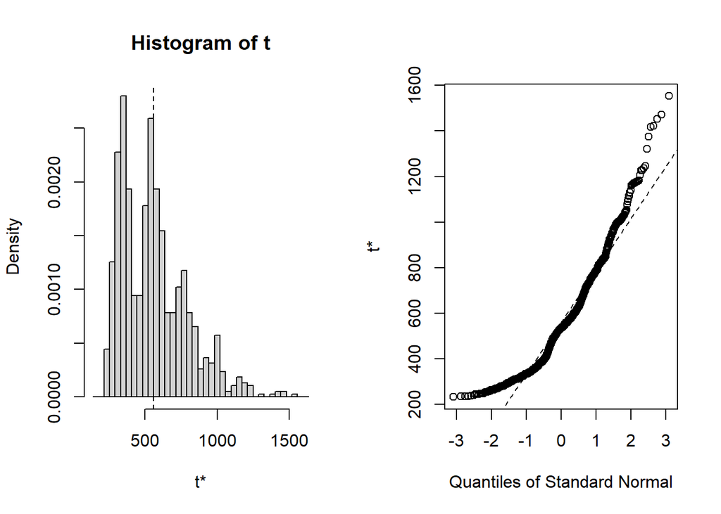

```
##    99.5%
## 525.6383
```

Here we leave a room for a possible mistakes in calculation, because usually risk loading is a small percentage of pure premium, but in our case it is larger than the pure premium.